# TP1 – Graphiques Quantile-Quantile, Test de Normalité et Test du χ²

Auteur·rice

HAMLIL Mohamed

Date de publication

2025

# Introduction

Dans ce TP, nous allons utiliser les outils de la **normalité** et de **l’indépendance** dans deux cadres :

- Sur **données ordonnées** (regroupées par modalités) : nous reconstruirons tous les outils à la main.
- Sur **données brutes** : nous utiliserons largement les fonctions de R.

**Objectifs pédagogiques :**

- Comprendre et tracer un QQ-plot
- Réaliser un test du χ² d’adéquation (normalité)
- Réaliser un test du χ² d’indépendance
- Utiliser les fonctions R pour tester la normalité (Shapiro-Wilk, `qqnorm`)

# 1. Le QQ-Plot (graphique quantile-quantile)

## 1.1 Rappels théoriques

Le **QQ-plot** (Quantile-Quantile plot) est un outil graphique qui permet de visualiser rapidement si une série de données suit une distribution théorique donnée (gaussienne, Poisson, etc.).

**Principe :**

**Interprétation :** Plus les points sont alignés sur la **diagonale**, plus l’adéquation de la loi théorique avec la loi observée est forte.

Pour des données regroupées par modalités $m_1, \ldots, m_J$ avec des fréquences cumulées $F_1, \ldots, F_J$, les quantiles théoriques d’une loi normale sont : $q_J^* = F_0^{-1}(F_J)$, accessibles via `qnorm(F_J, m, σ)`.

## 1.2 Application : tensions de pile

**Contexte :** Xantane a relevé 500 fois les tensions ($x_i$) de sa pile. Les données sont regroupées dans le tableau suivant :

| $x_i$ | 92 | 93 | 94 | 95 | 96 | 97 | 98 | 99 | 100 | 101 | 102 | 103 | 104 | 105 | 106 | 107 | 108 | 109 |
| --- | --- | --- | --- | --- | --- | --- | --- | --- | --- | --- | --- | --- | --- | --- | --- | --- | --- | --- |
| $n_i$ | 1 | 4 | 9 | 28 | 23 | 37 | 51 | 63 | 65 | 60 | 48 | 38 | 32 | 23 | 12 | 3 | 1 | 2 |

### Étape 1 : Saisie des données

```r
qi = 92:109
ni = c(1, 4, 9, 28, 23, 37, 51, 63, 65, 60, 48, 38, 32, 23, 12, 3, 1, 2)
```

### Étape 2 : Calcul de la moyenne pondérée

La moyenne pondérée se calcule comme : $m = \frac{\sum q_i \cdot n_i}{\sum n_i}$

```r
m = sum(qi * ni) / sum(ni)
cat("Moyenne pondérée m =", m)
```

```
Moyenne pondérée m = 100.068
```

### Étape 3 : Calcul de l’écart-type pondéré

$\sigma = \sqrt{\frac{\sum n_i (q_i - m)^2}{\sum n_i - 1}}$

```r
sigma = sqrt(sum(ni * (qi - m)^2) / (sum(ni) - 1))
cat("Écart-type pondéré sigma =", round(sigma, 2))
```

```
Écart-type pondéré sigma = 3.08
```

### Étape 4 : Fréquences cumulées et quantiles théoriques

```r
Fi = cumsum(ni) / sum(ni)
qietoile = qnorm(Fi, m, sigma)
```

### Étape 5 : Tracé du QQ-plot

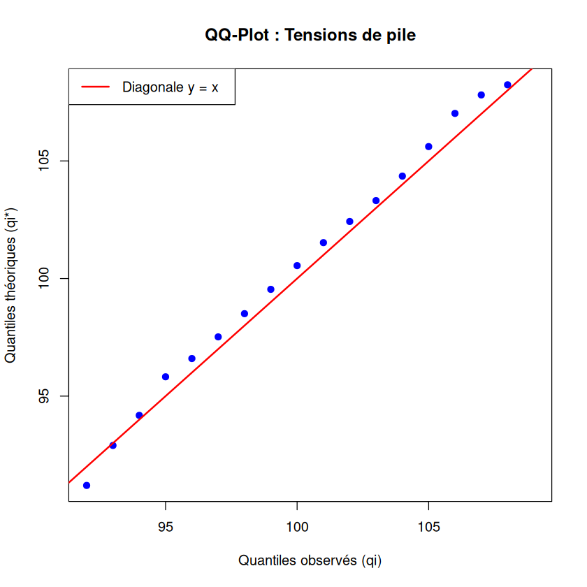

```r
plot(qi, qietoile,
     main = "QQ-Plot : Tensions de pile",
     xlab = "Quantiles observés (qi)",
     ylab = "Quantiles théoriques (qi*)",
     pch = 19, col = "blue")
lines(c(90, 110), c(90, 110), col = "red", lwd = 2)
legend("topleft", legend = "Diagonale y = x", col = "red", lwd = 2)
```

**Conclusion :** Les points sont bien alignés sur la diagonale. On observe une bonne adéquation avec une loi Normale $\mathcal{N}(m, \sigma)$.

# 2. Test du χ² pour la normalité

Puisque nous ne disposons pas des données brutes, nous ne pouvons pas faire un test de Shapiro-Wilk. Nous allons donc utiliser le **test du χ²** pour vérifier l’adéquation à la loi normale.

## 2.1 Fusion des effectifs faibles

Pour que le test du χ² soit valide, il faut que les effectifs théoriques soient supérieurs à 5. On fusionne donc les 2 premiers et les 3 derniers effectifs :

```r
ni2 = c(ni[1] + ni[2], ni[3:15], ni[16] + ni[17] + ni[18])
cat("Effectifs regroupés :", ni2)
```

```
Effectifs regroupés : 5 9 28 23 37 51 63 65 60 48 38 32 23 12 6
```

## 2.2 Calcul des probabilités théoriques

On calcule les probabilités théoriques $p_i$ en faisant la **correction de continuité** (bornes à ±0.5) :

```r
k = c(91, 93:106) + 0.5
K = c(93:106.5, 109) + 0.5
pi_theo = pnorm(K, 100, 3.1) - pnorm(k, 100, 3.1)
ti = 500 * pi_theo
```

## 2.3 Calcul de la statistique du χ²

```r
dchi = sum((ni2 - ti)^2 / ti)
cat("Statistique du chi-deux :", round(dchi, 4))
```

```
Statistique du chi-deux : 12.0494
```

On peut aussi utiliser la fonction `chisq.test` :

```r
chisq.test(ni2, p = pi_theo, rescale.p = TRUE)
```

```
    Chi-squared test for given probabilities

data:  ni2
X-squared = 11.991, df = 14, p-value = 0.607
```

## 2.4 Degrés de liberté et conclusion

**Attention !** Les degrés de liberté valent $15 - 1 - 2 = 12$ (car nous avons estimé 2 paramètres : $m$ et $\sigma$). Or `chisq.test()` n’utilise pas les bons d.d.l. et donne une p-value erronée.

Calculons la p-value correcte :

```r
cat("Quantile théorique χ²(0.95, 12) =", qchisq(0.95, 12))
cat("\nStatistique observée =", round(dchi, 4))
cat("\np-value correcte =", 1 - pchisq(dchi, 12))
```

```
Quantile théorique χ²(0.95, 12) = 21.02607
Statistique observée = 12.0494
p-value correcte = 0.4417218
```

**Conclusion :** La p-value est supérieure à 0.05 → on **ne rejette pas** l’hypothèse de normalité au seuil 5%.

# 3. Test du χ² d’indépendance

## 3.1 Importation des données du Titanic

Le fichier `titanic.csv` contient le registre des passagers du Titanic. L’objectif est d’étudier la relation entre **survie** et **classe** à l’aide du test d’indépendance de Chi-deux.

```r
titanic = read.csv("titanic.csv")
head(titanic)
```

A data.frame: 6 × 12

|  | PassengerId <int> | Survived <int> | Pclass <int> | Name <chr> | Sex <chr> | Age <dbl> | SibSp <int> | Parch <int> | Ticket <chr> | Fare <dbl> | Cabin <chr> | Embarked <chr> |
| --- | --- | --- | --- | --- | --- | --- | --- | --- | --- | --- | --- | --- |
| 1 | 1 | 0 | 3 | Braund. Mr. Owen Harris | male | 22 | 1 | 0 | A/5 21171 | 7.2500 |  | S |
| 2 | 2 | 1 | 1 | Cumings. Mrs. John Bradley (Florence Briggs Thayer) | female | 38 | 1 | 0 | PC 17599 | 71.2833 | C85 | C |
| 3 | 3 | 1 | 3 | Heikkinen. Miss. Laina | female | 26 | 0 | 0 | STON/O2. 3101282 | 7.9250 |  | S |
| 4 | 4 | 1 | 1 | Futrelle. Mrs. Jacques Heath (Lily May Peel) | female | 35 | 1 | 0 | 113803 | 53.1000 | C123 | S |
| 5 | 5 | 0 | 3 | Allen. Mr. William Henry | male | 35 | 0 | 0 | 373450 | 8.0500 |  | S |
| 6 | 6 | 0 | 3 | Moran. Mr. James | male | NA | 0 | 0 | 330877 | 8.4583 |  | Q |

Stockons les variables d’intérêt :

```r
survived = titanic$Survived
class = titanic$Pclass
head(survived)
head(class)
```

1. 0

2. 1

3. 1

4. 1

5. 0

6. 0

1. 3

2. 1

3. 3

4. 1

5. 3

6. 3

## 3.2 Test d’indépendance : Survie vs Classe

Construisons le **tableau de contingence** :

```r
contingence1 = table(survived, class)
contingence1
```

```
        class
survived   1   2   3
       0  80  97 372
       1 136  87 119
```

Effectuons le test du χ² d’indépendance :

```r
chisq.test(contingence1)
```

```
    Pearson's Chi-squared test

data:  contingence1
X-squared = 102.89, df = 2, p-value < 2.2e-16
```

**Interprétation :** La p-value est inférieure à 0.05 (pratiquement égale à 0) → on **rejette** significativement l’hypothèse d’indépendance. La classe et la survie sont **dépendantes**. *Malheureusement, on le savait…*

## 3.3 Autres tests d’indépendance

### Survie vs Sexe

```r
contingence_sex = table(survived, titanic$Sex)
contingence_sex
chisq.test(contingence_sex)
```

```
survived female male
       0     81  468
       1    233  109
```

```
    Pearson's Chi-squared test with Yates' continuity correction

data:  contingence_sex
X-squared = 260.72, df = 1, p-value < 2.2e-16
```

### Classe vs Port d’embarquement

```r
contingence2 = table(class, titanic$Embarked)
contingence2
```

```
class       C   Q   S
    1   2  85   2 127
    2   0  17   3 164
    3   0  66  72 353
```

On remarque une colonne vide (port inconnu). Supprimons-la :

```r
contingence2 = contingence2[, -1]
contingence2
chisq.test(contingence2)
```

```
class   C   Q   S
    1  85   2 127
    2  17   3 164
    3  66  72 353
```

```
    Pearson's Chi-squared test

data:  contingence2
X-squared = 123.75, df = 4, p-value < 2.2e-16
```

### Survie vs Port d’embarquement

```r
contingence3 = table(survived, titanic$Embarked)
contingence3 = contingence3[, -1]
chisq.test(contingence3)
```

```
    Pearson's Chi-squared test

data:  contingence3
X-squared = 26.489, df = 2, p-value = 1.77e-06
```

# 4. Normalité et fonctions de R

## 4.1 Acquisition de la variable `age`

```r
age = titanic$Age
head(age)
```

1. 22

2. 38

3. 26

4. 35

5. 35

6. <NA>

Certains âges sont manquants (NA). Gardons seulement les âges connus :

```r
age = age[!is.na(age)]
class2 = class[!is.na(titanic$Age)]
cat("Nombre d'âges valides :", length(age))
```

```
Nombre d'âges valides : 714
```

## 4.2 Normalité de `age`

### Densité estimée

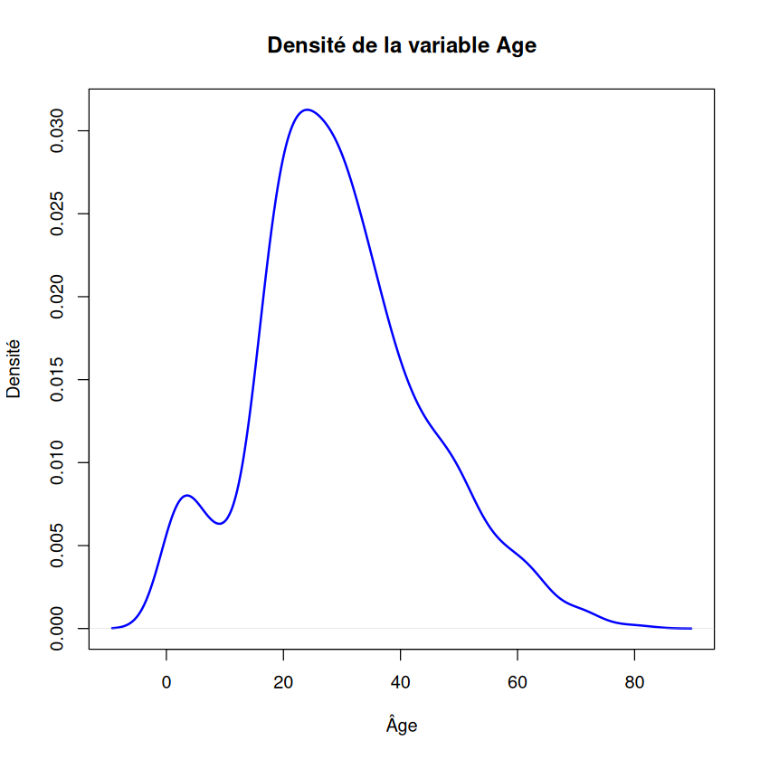

```r
plot(density(age),
     main = "Densité de la variable Age",
     xlab = "Âge", ylab = "Densité",
     col = "blue", lwd = 2)
```

### QQ-plot

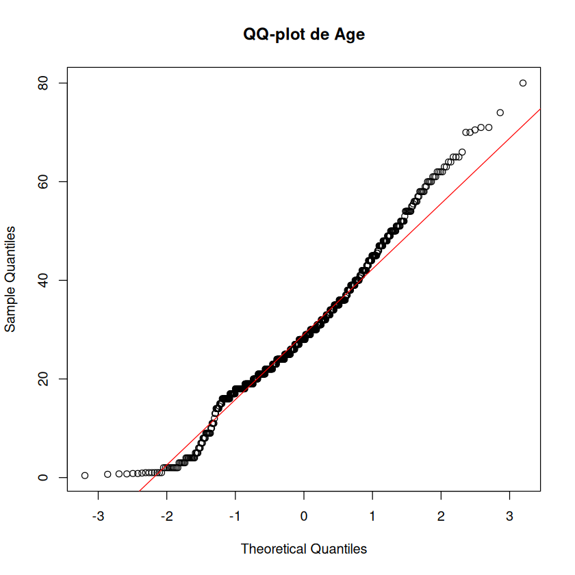

```r
qqnorm(age, main = "QQ-plot de Age")
qqline(age, col = "red")
```

### Test de Shapiro-Wilk

```r
shapiro.test(age)
```

```
    Shapiro-Wilk normality test

data:  age
W = 0.98146, p-value = 7.337e-08
```

**Conclusion :** La densité n’a pas l’allure d’une gaussienne, le QQ-plot dévie, et le test de Shapiro-Wilk rejette la normalité (p-value < 0.05). La variable `age` **n’est pas normale**.

## 4.3 Normalité de `age` par classe

La fonction `tapply` permet d’appliquer une fonction à une variable divisée par sous-groupes :

```r
tapply(age, class2, shapiro.test)
```

```
$`1`

    Shapiro-Wilk normality test

data:  X[[i]]
W = 0.99169, p-value = 0.3643


$`2`

    Shapiro-Wilk normality test

data:  X[[i]]
W = 0.97695, p-value = 0.005648


$`3`

    Shapiro-Wilk normality test

data:  X[[i]]
W = 0.97344, p-value = 4.186e-06
```

**Conclusion :** Seul en **première classe**, l’âge peut être considéré comme normal. Reste à savoir si cette information est vraiment intéressante…

# Résumé

| Outil | Utilisation | Fonction R |
| --- | --- | --- |
| QQ-plot | Visualiser l’adéquation à une loi | `qqnorm()`, `plot()` |
| Test χ² d’adéquation | Tester si les données suivent une loi | `chisq.test()` |
| Test χ² d’indépendance | Tester l’indépendance de 2 variables | `chisq.test(table())` |
| Test de Shapiro-Wilk | Tester la normalité (données brutes) | `shapiro.test()` |
| `tapply` | Appliquer une fonction par sous-groupe | `tapply(var, groupe, fun)` |